# Final Project: Shiyu Zhang

### Introduction:

The work focuses on a comprehensive study of tap water samples collected from seven metropolitan areas in the western United States between 2012 and 2015. The core objective of this research is to analyze the hydrogen (δ2H) and oxygen (δ18O) isotopes in tap water to understand the impact of water sources and elemental geochemistry of tap waters in highly populated regions. The cities involved in the study are Los Angeles-Long Beach-Santa Ana, Phoenix-Mesa-Glendale, Salt Lake City, San Diego-Carlsbad-San Marcos, San Francisco-Oakland-Fremont, San Jose-Sunnyvale-Santa Clara, and Riverside-San Bernardino-Ontario. Additionally, the work incorporates climate data such as precipitation, average temperature, and elevation from the National Climatic Data Center’s (NCDC) global historical weather and climate database, aiming to correlate these climate variables with the geochemistry of tap waters. Understanding the isotopic composition of tap water is crucial for water resource management, particularly in the face of climate change and increasing demand for water supplies. The insights from this study are essential for developing sustainable water management practices and policies that consider both local and regional environmental factors.

### **Dataset Abstract:**

The tap_water_OH dataset encompasses a comprehensive collection of tap water samples from seven populous metropolitan areas in the western United States, sampled between 2012 and 2015. The areas include Los Angeles-Long Beach-Santa Ana, Phoenix-Mesa-Glendale, Salt Lake City, San Diego-Carlsbad-San Marcos, San Francisco-Oakland-Fremont, San Jose-Sunnyvale-Santa Clara, and Riverside-San Bernardino-Ontario. The study focuses on measuring hydrogen (δ2H) and oxygen (δ18O) isotopes to assess the influence of water sources and management practices on the isotope and elemental geochemistry of tap waters. Precipitation, average temperature, and elevation climate data were downloaded from the NCDC’s archive, which holds a record of global historical weather and climate data. The temp_precip_7cities dataset covers the period from January 1, 2012, to December 31, 2015. Combine the tap water data with the climate data into a single dataset, which will be referred to as ‘OH_Climate_dataset’.

# Content

1. Basic Statistical Plots:
   - Single Variable Statistic Plots
   - Bivariate Plots
2. Clustering Analysis:
3. Multiple Variable Plots:
   - PCA Plot
   - Correlation Heatmap
   - Parallel Coordinate Plot
4. Mapping:
   - Basic Visualizations on Map
5. Geospatial analysis:
   - Spatial Clustering of Observations
   - Multiple Linear Regression

## **1 Basic Statistical Plots**

### Single Variable Statistic Plots

```r
# Load necessary libraries
library(ggplot2)
library(gridExtra)
library(readr)
library(dplyr)
library(plyr)
library(zoo)
library(GGally)
library(corrplot)
library(maps)
library(sf)
library(dbscan)
library(gstat)
library(spdep)
library(spatialreg)
# Load the OH dataset
OH_Climate_dataset_path <- "/Users/zhangshiyu/Desktop/R Course/Final/OH_Climate_dataset.csv"
data <- read_csv(OH_Climate_dataset_path)
data <- data %>%
  filter(LATITUDE >= 24.396308, LATITUDE <= 49.384358,
         LONGITUDE >= -125.001651, LONGITUDE <= -66.93457)
data$DATE <- as.Date(data$DATE)
# Interpolate missing TAVG values
data$TAVG <- na.approx(data$TAVG, rule=2)
```

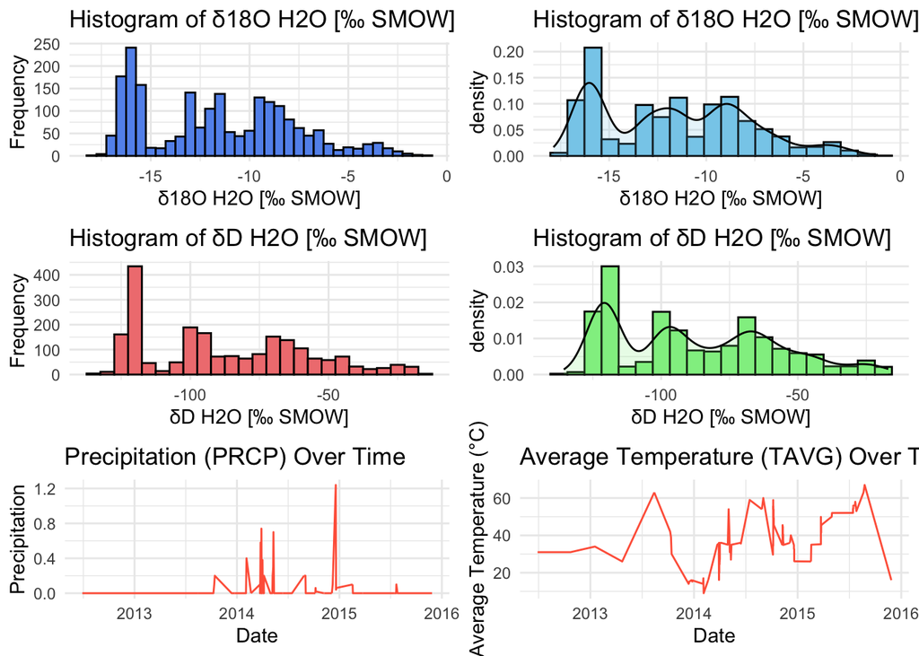

```r
## Single Variable Statistic Plots
# Histogram of δ18O H2O [‰ SMOW]
p1 <-  ggplot(data, aes(x=`δ18O H2O [‰ SMOW]`)) +
  geom_histogram(binwidth=0.5, fill="cornflowerblue", color="black") +
  ggtitle("Histogram of δ18O H2O [‰ SMOW]") +
  xlab("δ18O H2O [‰ SMOW]") + ylab("Frequency") +
  theme_minimal()

# Histogram of δ18O H2O [‰ SMOW] with KDE
p2 <- ggplot(data, aes(x=`δ18O H2O [‰ SMOW]`)) +
  geom_histogram(aes(y=..density..), bins=20, fill="skyblue", color="black") +
  geom_density(alpha=.2, fill="skyblue") +
  ggtitle("Histogram of δ18O H2O [‰ SMOW]") +
  theme_minimal()

# Histogram of δD H2O [‰ SMOW]
p3 <- ggplot(data, aes(x=`δD H2O [‰ SMOW]`)) +
  geom_histogram(binwidth=5, fill="lightcoral", color="black") +
  ggtitle("Histogram of δD H2O [‰ SMOW]") +
  xlab("δD H2O [‰ SMOW]") + ylab("Frequency") +
  theme_minimal()

# Histogram of δD H2O [‰ SMOW] with KDE
p4 <- ggplot(data, aes(x=`δD H2O [‰ SMOW]`)) +
  geom_histogram(aes(y=..density..), bins=20, fill="lightgreen", color="black") +
  geom_density(alpha=.2, fill="lightgreen") +
  ggtitle("Histogram of δD H2O [‰ SMOW]") +
  theme_minimal()

# Line plot for Precipitation  over time
p5 <- ggplot(data, aes(x=DATE, y=PRCP)) +
  geom_line(color="tomato") +
  ggtitle("Precipitation (PRCP) Over Time") +
  xlab("Date") + ylab("Precipitation") +
  theme_minimal()

# Line plot for Average Temperature (TAVG) over time
p6 <- ggplot(data, aes(x=DATE, y=TAVG)) +
  geom_line(color="tomato") +
  ggtitle("Average Temperature (TAVG) Over Time") +
  xlab("Date") + ylab("Average Temperature (°C)") +
  theme_minimal()

# Arrange the plots into a 3x2 grid
grid.arrange(p1, p2, p3, p4, p5, p6, ncol=2)
```

The single-variable statistical plots provided a foundational understanding of the distribution and central tendencies of individual variables within my dataset. Through histograms and density plots, I can identify skewness, outliers, and the general shape of data distributions.

### Bivariate Plots

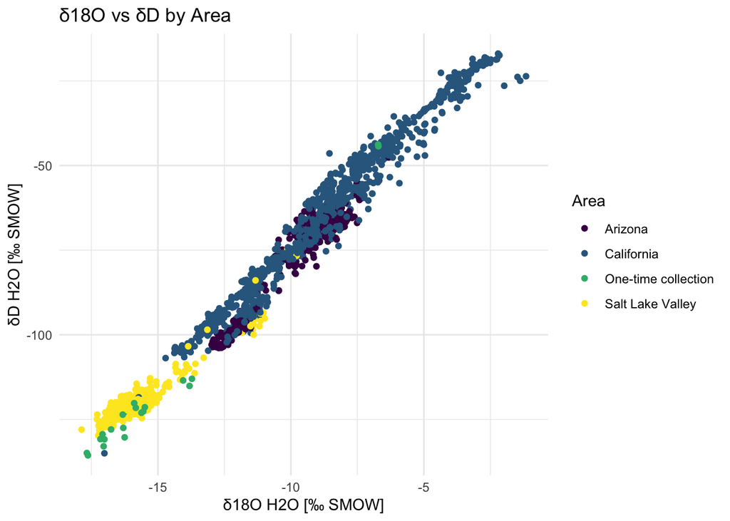

```r
## Bivariate plots
# Scatter Plot of δ18O vs δD
p7 <- ggplot(data, aes(x=`δ18O H2O [‰ SMOW]`, y=`δD H2O [‰ SMOW]`, color=Area)) +
  geom_point() +
  ggtitle("δ18O vs δD by Area") +
  xlab("δ18O H2O [‰ SMOW]") + ylab("δD H2O [‰ SMOW]") +
  theme_minimal() +
  scale_color_viridis_d() # Optional: Use a different color palette
plot(p7)
```

The scatter plot depicts the relationship between δ18O and δD(Deuterium: doo·tee·ree·uhm) values in tap water samples, color-coded by geographic areas: Arizona, California, one-time collection, and Salt Lake Valley, showing a positive correlation indicative of regional isotopic signatures.

## **2 Clustering Analysis**

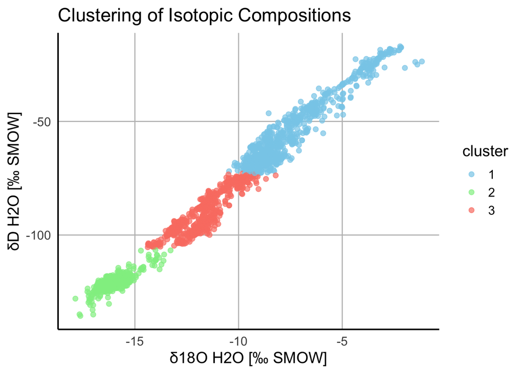

```r
## Clustering Analysis
# Prepare the isotopic data for clustering
isotopic_data <- data[, c("δ18O H2O [‰ SMOW]", "δD H2O [‰ SMOW]")]
isotopic_data <- na.omit(isotopic_data) # Removing rows with NA values to ensure kmeans can run

# Perform K-means clustering with 3 clusters
set.seed(123) # Set seed for reproducibility
kmeans_result <- kmeans(isotopic_data, centers = 3)
isotopic_data$cluster <- as.factor(kmeans_result$cluster) # Add the cluster assignments to your data

# Create the scatter plot
p8 <- ggplot(isotopic_data, aes(x=`δ18O H2O [‰ SMOW]`, y=`δD H2O [‰ SMOW]`, color=cluster)) +
  geom_point(alpha=0.7, size=2) +  # Adjust point transparency and size
  scale_color_manual(values=c("skyblue", "lightgreen", "salmon")) +  # Custom cluster colors
  labs(title="Clustering of Isotopic Compositions",
       x="δ18O H2O [‰ SMOW]", y="δD H2O [‰ SMOW]") +
  theme_minimal(base_size = 15) +  # Use a minimal theme with adjusted base font size
  theme(panel.grid.major = element_line(color = "grey", size = 0.5),  # Add major grid lines
        panel.grid.minor = element_blank(),  # Remove minor grid lines
        panel.background = element_blank(),  # Remove panel background
        axis.line = element_line(color = "black"))  # Add axis lines
plot(p8)
```

This scatter plot shows the clustering of water samples based on their isotopic composition, with each cluster (1, 2, and 3) representing a distinct group characterized by similar δ18O and δD values.

## **3 Mutipule Variable Plots**

### PCA Plot

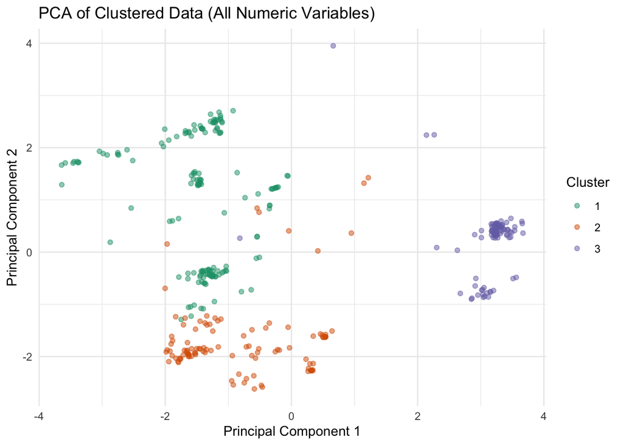

```r
## Mutipule Variable Plots
# Select only the numeric columns
numeric_data <- data[, sapply(data, is.numeric)]
numeric_data <- na.omit(numeric_data)

# Perform K-means clustering
kmeans_result_2 <- kmeans(numeric_data, centers = 3)
# Apply PCA for visualization purposes
pca_result <- prcomp(numeric_data, scale. = TRUE)

# Create a dataframe for plotting that includes PCA scores and cluster assignments
plot_data <- data.frame(PC1 = pca_result$x[, 1], PC2 = pca_result$x[, 2],
                        Cluster = as.factor(kmeans_result_2$cluster))

# PCA plot with ggplot2 showing clusters
p9 <- ggplot(plot_data, aes(x = PC1, y = PC2, color = Cluster)) +
  geom_point(alpha = 0.5) +
  scale_color_manual(values = c("#1b9e77", "#d95f02", "#7570b3")) +  # Adjust colors as needed
  labs(title = "PCA of Clustered Data (All Numeric Variables)",
       x = "Principal Component 1", y = "Principal Component 2") +
  theme_minimal()
plot(p9)
```

The PCA plot visualizes the distribution of clustered data points based on all numeric variables, with points grouped into three distinct clusters along the first two principal components reflecting the greatest variance.

### Correlation Heatmap

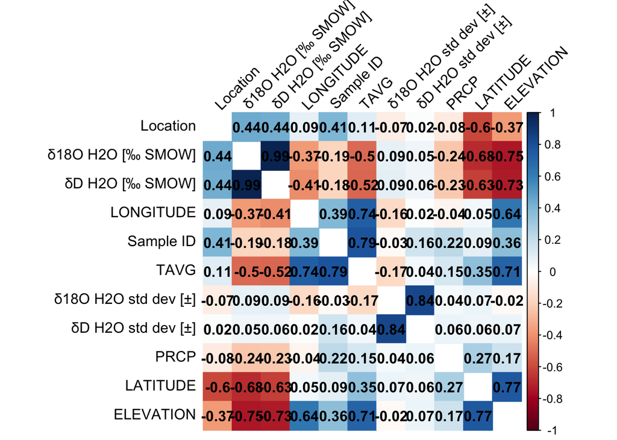

```r
# Plot of correlation heatmap
cor_matrix <- cor(numeric_data, use = "complete.obs") # Correlation matrix
p10 <- corrplot(cor_matrix, method = "color",
               order = "hclust", tl.col = "black", tl.srt = 45,
               # Add more customization options as needed
               addCoef.col = "black",  # Add correlation coefficients
               diag = FALSE)  # Do not show diagonal
```

### Parallel Coordinate Plot

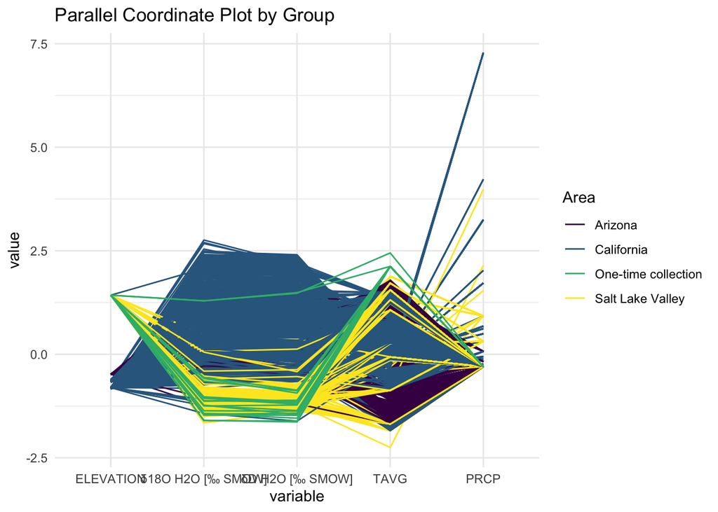

```r
# Parallel coordinate plot
# Select numeric variables for the parallel coordinate plot
parallel_vars <- data[, c("Area", "δ18O H2O [‰ SMOW]", "δD H2O [‰ SMOW]", "PRCP", "TAVG", "ELEVATION")]
parallel_vars$Area <- as.factor(parallel_vars$Area)
data_imputed <- sapply(parallel_vars, is.numeric)
parallel_vars[data_imputed] <- lapply(parallel_vars[data_imputed], function(x) ifelse(is.na(x), mean(x, na.rm = TRUE), x))
p11 <- ggparcoord(parallel_vars, columns = 2:6, groupColumn = 1, order = "anyClass") +
  theme_minimal() +
  labs(title = "Parallel Coordinate Plot by Group") +
  scale_color_viridis_d()
plot(p11)
```

The parallel coordinate plot illustrates multi-variable relationships and comparisons across different areas, with each line representing a set of related data points for Arizona, California, one-time collection, and Salt Lake Valley across various variables such as elevation, isotopic compositions, temperature, and precipitation.

## **4 Mapping**

### Basic Visualizations on Map

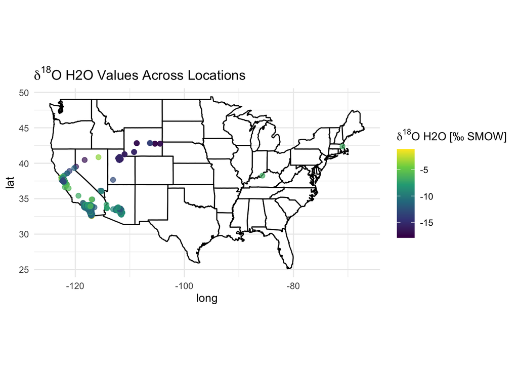

```r
## Mapping
# Base map with state boundaries
usa_map <- map_data("state")

# Plotting δ18O H2O [‰ SMOW] values on the map
m1 <-ggplot() +
  geom_polygon(data = usa_map, aes(x = long, y = lat, group = group),
               fill = "white", color = "black") +
  geom_point(data = data, aes(x = LONGITUDE, y = LATITUDE, color = `δ18O H2O [‰ SMOW]`),
             size = 2, alpha = 0.7) +
  scale_color_viridis_c(name = expression(delta^18*"O H2O [‰ SMOW]")) +
  labs(title = expression(delta^18*"O H2O Values Across Locations")) +
  theme_minimal() +
  coord_fixed(1.3) +
  theme(legend.position = "right")
plot(m1)
```

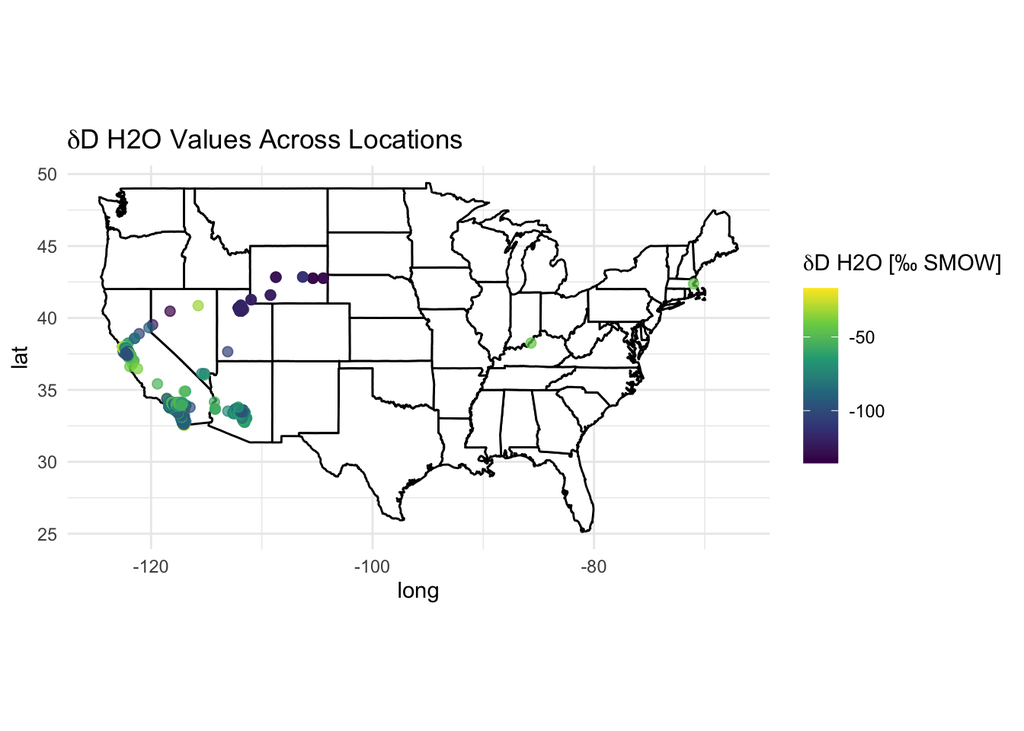

```r
# Plotting δD H2O [‰ SMOW] values on the map
m2 <-ggplot() +
  geom_polygon(data = usa_map, aes(x = long, y = lat, group = group),
               fill = "white", color = "black") +
  geom_point(data = data, aes(x = LONGITUDE, y = LATITUDE, color = `δD H2O [‰ SMOW]`),
             size = 2, alpha = 0.7) +
  scale_color_viridis_c(name = expression(delta*D*" H2O [‰ SMOW]")) +
  labs(title = expression(delta*D*" H2O Values Across Locations")) +
  theme_minimal() +
  coord_fixed(1.3)
plot(m2)
```

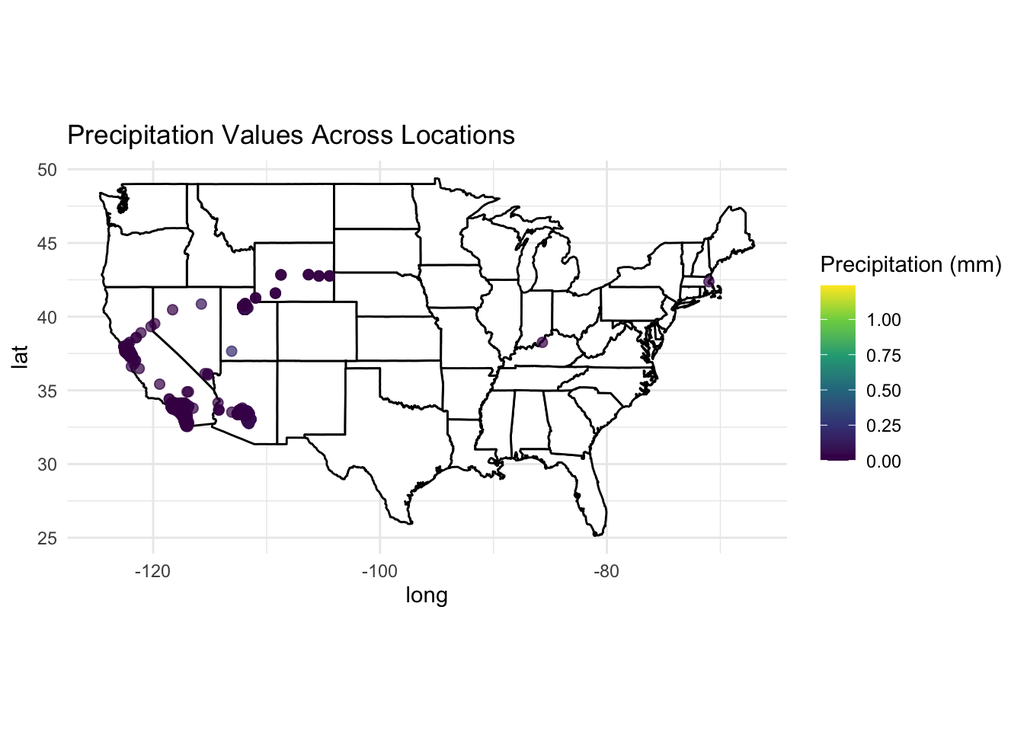

```r
# Visualization of Precipitation (PRCP)
m3 <- ggplot() +
  geom_polygon(data = usa_map, aes(x = long, y = lat, group = group),
               fill = "white", color = "black") +
  geom_point(data = data, aes(x = LONGITUDE, y = LATITUDE, color = PRCP),
             size = 2, alpha = 0.7) +
  scale_color_viridis_c(name = "Precipitation (mm)") +
  labs(title = "Precipitation Values Across Locations") +
  theme_minimal() +
  coord_fixed(1.3)
plot(m3)
```

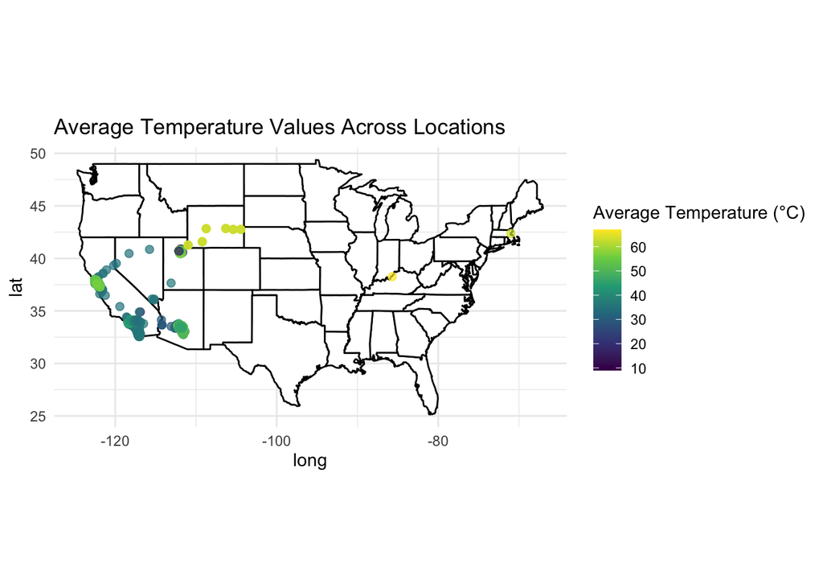

```r
# Visualization of Average Temperature (TAVG)
m4 <- ggplot() +
  geom_polygon(data = usa_map, aes(x = long, y = lat, group = group),
               fill = "white", color = "black") +
  geom_point(data = data, aes(x = LONGITUDE, y = LATITUDE, color = TAVG),
             size = 2, alpha = 0.7) +
  scale_color_viridis_c(name = "Average Temperature (°C)") +
  labs(title = "Average Temperature Values Across Locations") +
  theme_minimal() +
  coord_fixed(1.3)
plot(m4)
```

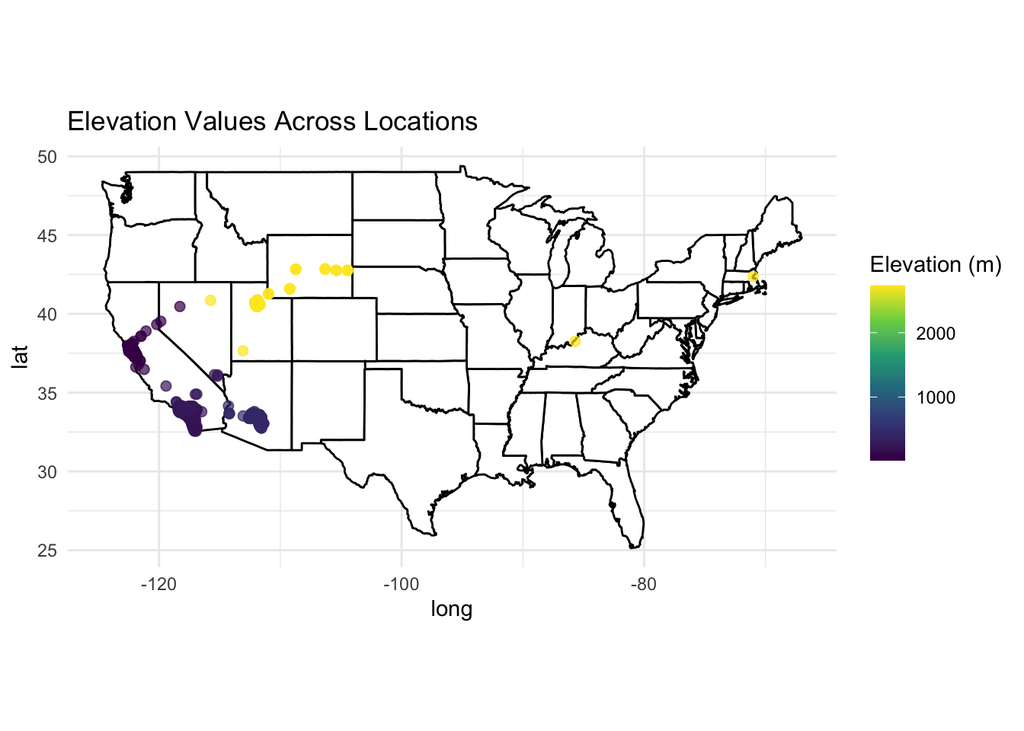

```r
# Visualization of Elevation (ELEVATION)
m5 <- ggplot() +
  geom_polygon(data = usa_map, aes(x = long, y = lat, group = group),
               fill = "white", color = "black") +
  geom_point(data = data, aes(x = LONGITUDE, y = LATITUDE, color = ELEVATION),
             size = 2, alpha = 0.7) +
  scale_color_viridis_c(name = "Elevation (m)") +
  labs(title = "Elevation Values Across Locations") +
  theme_minimal() +
  coord_fixed(1.3)
plot(m5)
```

## **5 Geospatial analysis**

### Spatial Clustering of Observations

```r
## Geospatial analysis
# Basic Geospatial Visualization
data_sf <- st_as_sf(data, coords = c("LONGITUDE", "LATITUDE"), crs = 4326) # Convert to an sf object
# Perform DBSCAN clustering (example parameters)
coords <- st_coordinates(data_sf)# Extract coordinates
geo_cluster_result <- dbscan(coords, eps = 0.1, minPts = 5)
data_sf$cluster <- geo_cluster_result$cluster # Add cluster assignments back to the data

# Plot of Spatial Clustering of Observations with US State Boundaries
m6 <- ggplot() +
  geom_polygon(data = usa_map, aes(x = long, y = lat, group = group), fill = "white", color = "black", size = 0.25) +
  geom_sf(data = data_sf, aes(color = cluster), show.legend = "point") +
  labs(title = "Spatial Clustering of Observations with US State Boundaries") +
  theme_minimal() +
  theme(legend.position = "right")
plot(m6)
```

[figure not shown]

### Multiple Linear Regression

```r
# Multiple linear regression including cluster as a categorical variable
data_sf$cluster <- as.factor(data_sf$cluster)
model_with_clusters <- lm(`δ18O H2O [‰ SMOW]` ~ `δD H2O [‰ SMOW]` + PRCP + TAVG + ELEVATION + cluster, data = data_sf)
summary(model_with_clusters)
```

```
##
## Call:
## lm(formula = `δ18O H2O [‰ SMOW]` ~ `δD H2O [‰ SMOW]` +
##     PRCP + TAVG + ELEVATION + cluster, data = data_sf)
##
## Residuals:
##      Min       1Q   Median       3Q      Max
## -1.97702 -0.27006 -0.04904  0.24493  2.05965
##
## Coefficients:
##                     Estimate Std. Error t value Pr(>|t|)
## (Intercept)       -8.573e-01  7.687e-02 -11.153  < 2e-16 ***
## `δD H2O [‰ SMOW]`  1.249e-01  5.302e-04 235.546  < 2e-16 ***
## PRCP              -7.753e-02  6.198e-02  -1.251  0.21107
## TAVG               8.979e-03  8.171e-04  10.988  < 2e-16 ***
## ELEVATION         -6.720e-05  4.556e-05  -1.475  0.14037
## cluster1          -1.686e-01  9.692e-02  -1.739  0.08215 .
## cluster2          -1.800e-01  6.383e-02  -2.820  0.00485 **
## cluster3           8.009e-01  7.531e-02  10.634  < 2e-16 ***
## cluster4          -2.540e-01  6.319e-02  -4.020 6.01e-05 ***
## cluster5           3.271e-01  5.857e-02   5.585 2.63e-08 ***
## cluster6           1.423e-01  1.680e-01   0.847  0.39694
## ---
## Signif. codes:  0 '***' 0.001 '**' 0.01 '*' 0.05 '.' 0.1 ' ' 1
##
## Residual standard error: 0.4514 on 2097 degrees of freedom
## Multiple R-squared:  0.9858, Adjusted R-squared:  0.9858
## F-statistic: 1.461e+04 on 10 and 2097 DF,  p-value: < 2.2e-16
```

```r
# Find the k-nearest neighbors for each point
knn_result <- knearneigh(coords, k=4)
# Convert the result to a neighbors list
neighbors <- knn2nb(knn_result, sym=TRUE) # sym=TRUE makes the neighbors relationship symmetric
# Convert neighbors list to a listw object
listw <- nb2listw(neighbors, style="W", zero.policy=TRUE)

# Fit a spatial lag model using spatialreg
model_lag <- spatialreg::lagsarlm(`δ18O H2O [‰ SMOW]` ~ `δD H2O [‰ SMOW]` + PRCP + TAVG + ELEVATION, data = data_sf, listw = listw)
summary(model_lag)
```

```
##
## Call:
## spatialreg::lagsarlm(formula = `δ18O H2O [‰ SMOW]` ~ `δD H2O [‰ SMOW]` +
##     PRCP + TAVG + ELEVATION, data = data_sf, listw = listw)
##
## Residuals:
##       Min        1Q    Median        3Q       Max
## -2.091203 -0.335917 -0.072859  0.287751  2.455920
##
## Type: lag
## Coefficients: (asymptotic standard errors)
##                      Estimate  Std. Error  z value  Pr(>|z|)
## (Intercept)       -8.0419e-01  6.1189e-02 -13.1426 < 2.2e-16
## `δD H2O [‰ SMOW]`  1.1871e-01  8.9452e-04 132.7112 < 2.2e-16
## PRCP              -3.1016e-01  6.8273e-02  -4.5429 5.547e-06
## TAVG               8.6750e-03  9.0177e-04   9.6199 < 2.2e-16
## ELEVATION         -1.0273e-04  1.6341e-05  -6.2864 3.249e-10
##
## Rho: 0.051343, LR test value: 39.743, p-value: 2.8966e-10
## Asymptotic standard error: 0.0083115
##     z-value: 6.1773, p-value: 6.5193e-10
## Wald statistic: 38.159, p-value: 6.5193e-10
##
## Log likelihood: -1561.224 for lag model
## ML residual variance (sigma squared): 0.2574, (sigma: 0.50735)
## Number of observations: 2108
## Number of parameters estimated: 7
## AIC: 3136.4, (AIC for lm: 3174.2)
## LM test for residual autocorrelation
## test value: 942.08, p-value: < 2.22e-16
```

- Multiple Linear Regression:
  - δD H2O and TAVG have highly significant positive effects on δ18O H2O.
  - Clusters 2, 3, 4, and 5 show significant effects, indicating that water samples from these clusters have distinct isotopic signatures.
  - Precipitation and Elevation are not significant predictors in this model.
  - The model explains a very high proportion of the variance (R-squared = 0.9858), indicating a good fit.
- Spatial Lag Model:
  - The inclusion of the spatial lag component (Rho) indicates that there is spatial dependence in the data.
  - PRCP becomes significant with a negative coefficient, suggesting an inverse relationship with δ18O H2O when accounting for spatial dependence.
  - Elevation also becomes significant with a negative coefficient, differing from the multiple linear regression model.
  - The AIC is lower than that of the non-spatial model, suggesting a better fit with the inclusion of the spatial lag.

Conclusions: